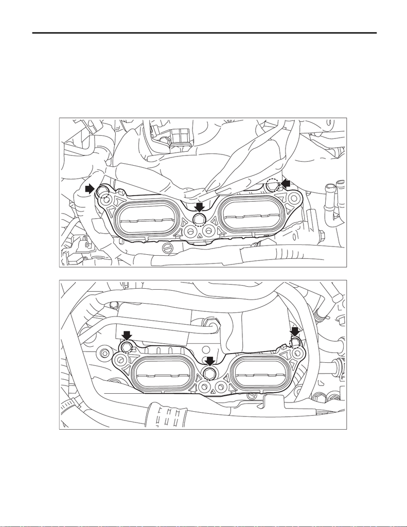

Tumble Generator Valve Assembly

FUEL INJECTION (FUEL SYSTEMS)

4. Tumble Generator Valve Assembly

A: REMOVAL

NOTE:

The tumble generator valve assembly is tightened together with the intake manifold.

1) Disconnect the ground terminal from battery sensor. <Ref. to NT-5, BATTERY, NOTE, Note.>

2) Remove the intake manifold. <Ref. to FU(w/o STI)-18, REMOVAL, Intake Manifold.>

3) Remove the air intake adapter from the cylinder head.

• RH side

•LH side

FU-08321

FU-07363

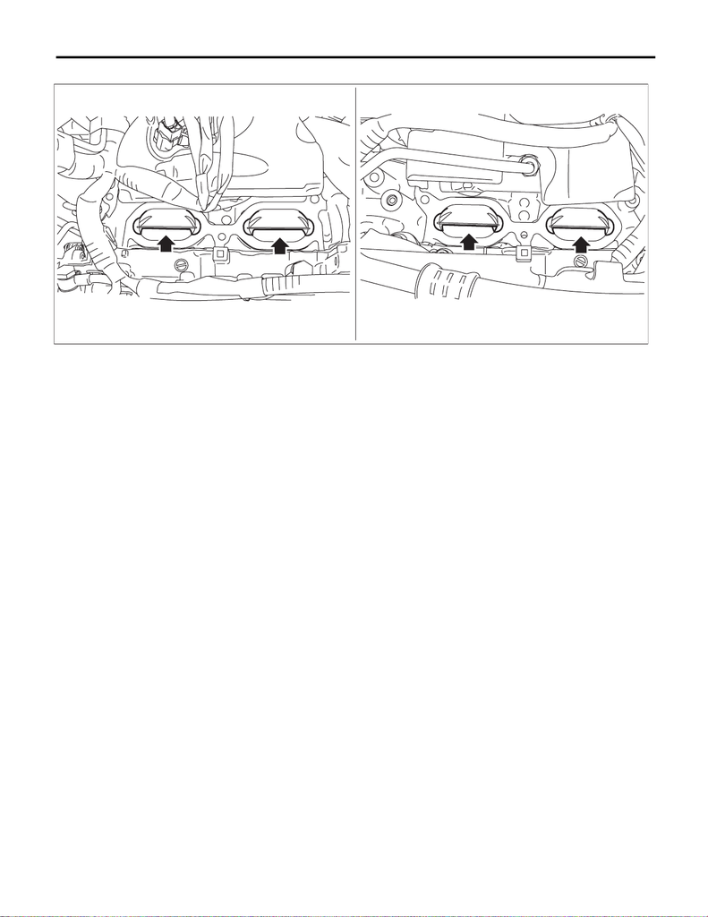

Tumble Generator Valve Assembly

FUEL INJECTION (FUEL SYSTEMS)

4) Remove the cylinder head plate from cylinder head.

B: INSTALLATION

Install in the reverse order of removal.

NOTE:

Use a new gasket.

Tightening torque:

25 N·m (2.5 kgf-m, 18.4 ft-lb)

C: INSPECTION

2) Check tumble generator valve assembly or air intake adapter for contamination or clogging.

FU-08322